# Final Assignment

Venkat Ganesh

1/4/2021

## Summary

This problem involved predicting the type of activity based on predictor variables obtained from measurements of accelerometers. The first step of my approach was to see if I could do any data cleaning. It was immediately apparent that there were columns with NA measurements, so I wanted to exclude these from my predictors. I also observed some variables which I did not believe would have any predictive capabilities so I removed those. Lastly I used the nearZeroVar function to remove predictors with variances near 0, as these would not have much predictive power. After cleaning, my first modeling approach was to fit a classification tree. This would give us a relatively fast model fit, along with outputting interpretable results. The model ended up being not very accurate, getting an accuracy around 50%. So I instead tried a Random Forest model, which ended up giving me a 99.5% accuracy on the holdout set, and yielded 100% results in the out of sample test set provided for us.

## Read Data and load packages

```r
knitr::opts_chunk$set(echo = TRUE)
library(caret)
library(dplyr)
library(rattle)
```

```r
train_raw <- read.csv("https://d396qusza40orc.cloudfront.net/predmachlearn/pml-training.csv")
test_raw <- read.csv("https://d396qusza40orc.cloudfront.net/predmachlearn/pml-testing.csv")
```

## data cleaning

```r
head_data <- head(train_raw,5)
train <- train_raw[, colSums(is.na(train_raw)) == 0]
test <- test_raw[, colSums(is.na(test_raw)) == 0]
train <- train[,!(colnames(train) %in% c("X","user_name","raw_timestamp_part_1","raw_timestamp_part_2","cvtd_timestamp","new_window","num_window"))]
train$classe <- as.factor(train$classe)
nearzerocolumns <- nearZeroVar(train)
train <- train[, -nearzerocolumns]
```

## Classification Tree Modeling

```r
set.seed(14231)
trainIndex <- createDataPartition(train$classe, p = 0.75)[[1]]
validation <- train[-trainIndex,]
train <- train[trainIndex,]
modelFit <- train(classe~.,method = "rpart",data = train)
modelTest <- predict(modelFit, validation)
confusionMatrix(modelTest, validation$classe)
```

```
## Confusion Matrix and Statistics
##
##           Reference
## Prediction   A   B   C   D   E
##          A 845 135  25  36  13
##          B 109 419 100  44  86
##          C 318 173 398 125 179
##          D 118 220 332 514 119
##          E   5   2   0  85 504
##
## Overall Statistics
##
##                Accuracy : 0.5465
##                  95% CI : (0.5324, 0.5605)
##     No Information Rate : 0.2845
##     P-Value [Acc > NIR] : < 2.2e-16
##
##                   Kappa : 0.4336
##
##  Mcnemar's Test P-Value : < 2.2e-16
##
## Statistics by Class:
##
##                      Class: A Class: B Class: C Class: D Class: E
## Sensitivity            0.6057  0.44152  0.46550   0.6393   0.5594
## Specificity            0.9404  0.91429  0.80366   0.8076   0.9770
## Pos Pred Value         0.8017  0.55277  0.33361   0.3945   0.8456
## Neg Pred Value         0.8571  0.87217  0.87685   0.9195   0.9078
## Prevalence             0.2845  0.19352  0.17435   0.1639   0.1837
## Detection Rate         0.1723  0.08544  0.08116   0.1048   0.1028
## Detection Prevalence   0.2149  0.15457  0.24327   0.2657   0.1215
## Balanced Accuracy      0.7731  0.67790  0.63458   0.7234   0.7682
```

## Classification tree

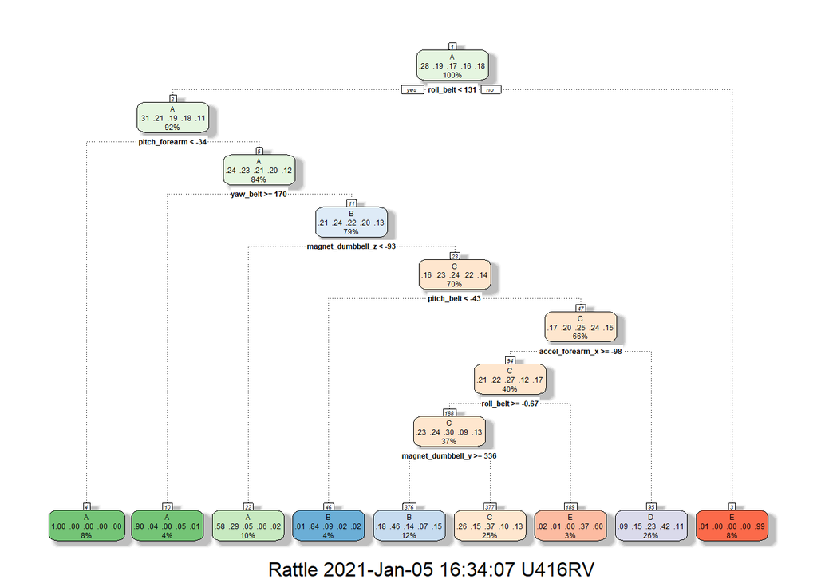

```r
fancyRpartPlot(modelFit$finalModel)
```

## Random Forest Modeling

```r
set.seed(14232)
modelFit_rf <- train(classe~.,method = "rf",data = train, allowParallel=TRUE)
modelTest_rf <- predict(modelFit_rf, validation)
confusionMatrix(modelTest_rf, validation$classe)
```

```
## Confusion Matrix and Statistics
##
##           Reference
## Prediction    A    B    C    D    E
##          A 1393    5    0    0    0
##          B    2  942    2    0    0
##          C    0    1  853   11    0
##          D    0    0    0  792    2
##          E    0    1    0    1  899
##
## Overall Statistics
##
##                Accuracy : 0.9949
##                  95% CI : (0.9925, 0.9967)
##     No Information Rate : 0.2845
##     P-Value [Acc > NIR] : < 2.2e-16
##
##                   Kappa : 0.9936
##
##  Mcnemar's Test P-Value : NA
##
## Statistics by Class:
##
##                      Class: A Class: B Class: C Class: D Class: E
## Sensitivity            0.9986   0.9926   0.9977   0.9851   0.9978
## Specificity            0.9986   0.9990   0.9970   0.9995   0.9995
## Pos Pred Value         0.9964   0.9958   0.9861   0.9975   0.9978
## Neg Pred Value         0.9994   0.9982   0.9995   0.9971   0.9995
## Prevalence             0.2845   0.1935   0.1743   0.1639   0.1837
## Detection Rate         0.2841   0.1921   0.1739   0.1615   0.1833
## Detection Prevalence   0.2851   0.1929   0.1764   0.1619   0.1837
## Balanced Accuracy      0.9986   0.9958   0.9973   0.9923   0.9986
```

# Out of Sample Results

```r
predict(modelFit_rf, test)
```

```
##  [1] B A B A A E D B A A B C B A E E A B B B
## Levels: A B C D E
```